# הסבר + EDA

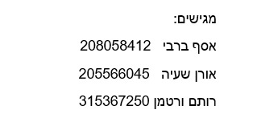

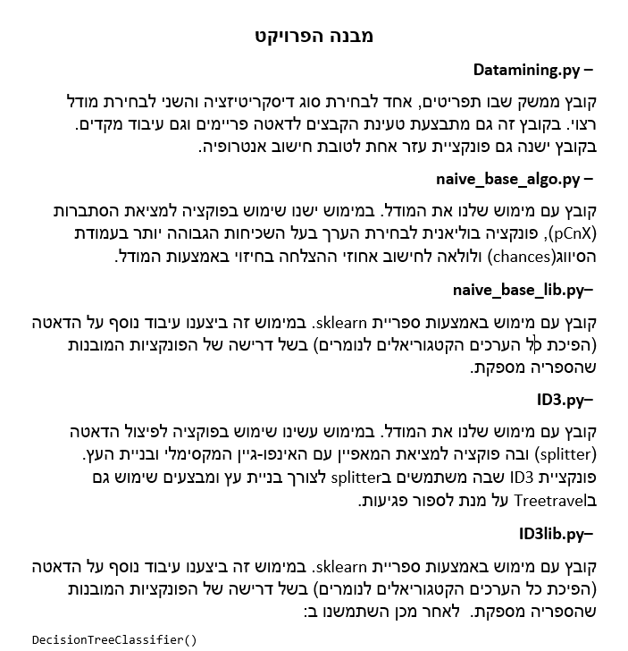

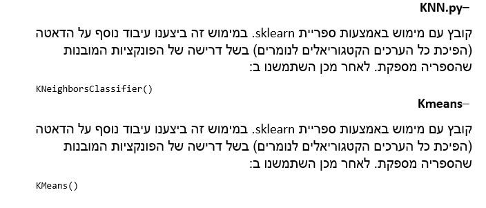

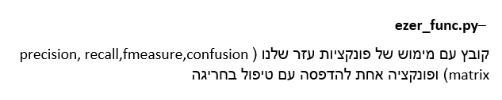

```python
import numpy as np
import pandas as pd
fileName = 'Structure'
struct = pd.read_csv(fileName+".txt",sep="\s+", header=None, names=['attribute','values'])

struct
```

|  | attribute | values |
| --- | --- | --- |
| @ATTRIBUTE | age | NUMERIC |
| @ATTRIBUTE | job | {admin.,unknown,unemployed,management,housemai... |
| @ATTRIBUTE | marital | {married,divorced,single,widowed} |
| @ATTRIBUTE | education | {unknown,secondary,primary,tertiary} |
| @ATTRIBUTE | default | {yes,no} |
| @ATTRIBUTE | balance | NUMERIC |
| @ATTRIBUTE | housing | {yes,no} |
| @ATTRIBUTE | loan | {yes,no} |
| @ATTRIBUTE | contact | {unknown,telephone,cellular} |
| @ATTRIBUTE | day | NUMERIC |
| @ATTRIBUTE | month | {jan,feb,mar,apr,may,jun,jul,aug,sep,oct,nov,dec} |
| @ATTRIBUTE | duration | NUMERIC |
| @ATTRIBUTE | campaign | NUMERIC |
| @ATTRIBUTE | previous | NUMERIC |
| @ATTRIBUTE | poutcome | {unknown,other,failure,success} |
| @ATTRIBUTE | class | {yes,no} |

ניתן לראות את המאפיינים שקיימים בבסיס הנתונים, יש מאפיינים בעלי ערכים נומריים ויש בעלי ערכים קטגוריאלים. בהמשך נבצע דיסקרטיזציה לערכים הנומריים..

```python
fileName = 'train'
train = pd.read_csv(fileName+'.csv')

train
```

|  | age | job | marital | education | default | balance | housing | loan | contact | day | month | duration | campaign | previous | poutcome | class |
| --- | --- | --- | --- | --- | --- | --- | --- | --- | --- | --- | --- | --- | --- | --- | --- | --- |
| 0 | 58 | management | married | tertiary | no | 2143.0 | yes | no | unknown | 5 | may | 261.0 | 1 | 0 | unknown | no |
| 1 | 44 | technician | single | secondary | no | 29.0 | yes | no | unknown | 5 | may | 151.0 | 1 | 0 | unknown | no |
| 2 | 33 | entrepreneur | married | secondary | no | 2.0 | yes | yes | unknown | 5 | may | 76.0 | 1 | 0 | unknown | no |
| 3 | 47 | blue-collar | married | unknown | no | 1506.0 | yes | no | unknown | 5 | may | 92.0 | 1 | 0 | unknown | no |
| 4 | 33 | unknown | single | unknown | no | 1.0 | no | no | unknown | 5 | may | 198.0 | 1 | 0 | unknown | no |
| 5 | 35 | management | married | tertiary | no | 231.0 | yes | no | unknown | 5 | may | 139.0 | 1 | 0 | unknown | no |
| 6 | 28 | management | single | tertiary | no | 447.0 | yes | yes | unknown | 5 | may | 217.0 | 1 | 0 | unknown | no |
| 7 | 42 | entrepreneur | divorced | tertiary | yes | 2.0 | yes | no | unknown | 5 | may | 380.0 | 1 | 0 | unknown | no |
| 8 | 58 | retired | married | primary | no | 121.0 | yes | no | unknown | 5 | may | 50.0 | 1 | 0 | unknown | no |
| 9 | 43 | technician | single | secondary | no | 593.0 | yes | no | unknown | 5 | may | 55.0 | 1 | 0 | unknown | no |
| 10 | 41 | admin. | divorced | secondary | no | 270.0 | yes | no | unknown | 5 | may | 222.0 | 1 | 0 | unknown | no |
| 11 | 29 | admin. | single | secondary | no | 390.0 | yes | no | unknown | 5 | may | 137.0 | 1 | 0 | unknown | no |
| 12 | 53 | technician | married | secondary | no | 6.0 | yes | no | unknown | 5 | may | 517.0 | 1 | 0 | unknown | no |
| 13 | 58 | technician | married | unknown | no | 71.0 | yes | no | unknown | 5 | may | 71.0 | 1 | 0 | unknown | no |
| 14 | 57 | services | married | secondary | no | 162.0 | yes | no | unknown | 5 | may | 174.0 | 1 | 0 | unknown | no |
| 15 | 51 | retired | married | primary | no | 229.0 | yes | no | unknown | 5 | may | 353.0 | 1 | 0 | unknown | no |
| 16 | 45 | admin. | single | unknown | no | 13.0 | yes | no | unknown | 5 | may | 98.0 | 1 | 0 | unknown | no |
| 17 | 57 | blue-collar | married | primary | no | 52.0 | yes | no | unknown | 5 | may | 38.0 | 1 | 0 | unknown | no |
| 18 | 60 | retired | married | primary | no | 60.0 | yes | no | unknown | 5 | may | 219.0 | 1 | 0 | unknown | no |
| 19 | 33 | services | married | secondary | no | 0.0 | yes | no | unknown | 5 | may | NaN | 1 | 0 | unknown | no |
| 20 | 28 | blue-collar | married | secondary | no | 723.0 | yes | yes | unknown | 5 | may | 262.0 | 1 | 0 | unknown | no |
| 21 | 56 | management | married | tertiary | no | 779.0 | yes | no | unknown | 5 | may | 164.0 | 1 | 0 | unknown | no |
| 22 | 32 | blue-collar | single | primary | no | 23.0 | yes | yes | unknown | 5 | may | 160.0 | 1 | 0 | unknown | no |
| 23 | 25 | services | married | secondary | no | 50.0 | yes | no | unknown | 5 | may | 342.0 | 1 | 0 | unknown | no |
| 24 | 40 | retired | married | primary | no | 0.0 | yes | yes | unknown | 5 | may | 181.0 | 1 | 0 | unknown | no |
| 25 | 44 | admin. | married | secondary | no | -372.0 | yes | no | unknown | 5 | may | 172.0 | 1 | 0 | unknown | no |
| 26 | 39 | management | single | tertiary | no | 255.0 | yes | no | unknown | 5 | may | 296.0 | 1 | 0 | unknown | no |
| 27 | 52 | entrepreneur | married | secondary | no | 113.0 | yes | yes | unknown | 5 | may | NaN | 1 | 0 | unknown | no |
| 28 | 46 | management | single | secondary | no | -246.0 | yes | no | unknown | 5 | may | 255.0 | 2 | 0 | unknown | no |
| 29 | 36 | technician | single | secondary | no | 265.0 | yes | yes | unknown | 5 | may | 348.0 | 1 | 0 | unknown | no |
| ... | ... | ... | ... | ... | ... | ... | ... | ... | ... | ... | ... | ... | ... | ... | ... | ... |
| 42150 | 69 | technician | married | tertiary | no | 482.0 | no | no | cellular | 4 | nov | 101.0 | 1 | 0 | unknown | no |
| 42151 | 29 | admin. | single | secondary | no | 2.0 | no | no | cellular | 4 | nov | 85.0 | 1 | 1 | failure | no |
| 42152 | 42 | management | married | tertiary | no | 520.0 | no | no | cellular | 4 | nov | 158.0 | 1 | 0 | unknown | no |
| 42153 | 34 | management | married | tertiary | no | 1778.0 | no | no | cellular | 4 | nov | 358.0 | 1 | 2 | failure | yes |
| 42154 | 61 | management | married | tertiary | no | 6016.0 | no | no | cellular | 4 | nov | 199.0 | 1 | 3 | success | no |
| 42155 | 34 | management | married | tertiary | no | 527.0 | no | no | cellular | 4 | nov | 272.0 | 1 | 0 | unknown | no |
| 42156 | 33 | management | single | tertiary | no | 5276.0 | no | no | cellular | 4 | nov | 572.0 | 1 | 0 | unknown | no |
| 42157 | 31 | management | single | tertiary | no | 220.0 | yes | no | cellular | 4 | nov | 257.0 | 2 | 2 | failure | no |
| 42158 | 49 | technician | married | secondary | no | 402.0 | no | no | cellular | 5 | nov | 76.0 | 2 | 0 | unknown | no |
| 42159 | 42 | management | married | tertiary | no | 603.0 | yes | no | cellular | 5 | nov | 298.0 | 5 | 0 | unknown | no |
| 42160 | 78 | retired | divorced | primary | no | 55.0 | no | no | telephone | 5 | nov | 143.0 | 3 | 1 | other | no |
| 42161 | 55 | blue-collar | married | secondary | no | 12401.0 | no | no | telephone | 5 | nov | 111.0 | 9 | 4 | other | no |
| 42162 | 73 | retired | married | secondary | no | 19.0 | no | no | cellular | 5 | nov | 509.0 | 2 | 0 | unknown | no |
| 42163 | 54 | technician | married | secondary | no | 0.0 | no | no | cellular | 6 | nov | 464.0 | 5 | 8 | other | yes |
| 42164 | 78 | retired | married | tertiary | no | 226.0 | no | no | telephone | 6 | nov | 136.0 | 1 | 0 | unknown | no |
| 42165 | 31 | technician | married | secondary | no | 2440.0 | no | no | cellular | 6 | nov | 312.0 | 1 | 0 | unknown | no |
| 42166 | 60 | technician | married | tertiary | no | 6573.0 | yes | no | cellular | 6 | nov | 126.0 | 2 | 2 | failure | no |
| 42167 | 67 | retired | married | primary | no | 942.0 | no | no | cellular | 6 | nov | 455.0 | 2 | 2 | other | yes |
| 42168 | 24 | technician | married | secondary | no | 556.0 | yes | no | cellular | 6 | nov | 368.0 | 2 | 2 | success | yes |
| 42169 | 33 | technician | married | tertiary | no | 1699.0 | no | no | cellular | 6 | nov | 178.0 | 2 | 1 | success | yes |
| 42170 | 33 | technician | married | secondary | no | 6699.0 | no | no | cellular | 9 | nov | 425.0 | 1 | 1 | failure | no |
| 42171 | 53 | admin. | married | secondary | no | 10541.0 | no | no | cellular | 9 | nov | 178.0 | 1 | 0 | unknown | yes |
| 42172 | 33 | student | married | secondary | no | 1536.0 | no | no | cellular | 9 | nov | 262.0 | 1 | 2 | success | yes |
| 42173 | 24 | student | single | tertiary | no | 235.0 | no | no | cellular | 9 | nov | 118.0 | 1 | 0 | unknown | yes |
| 42174 | 32 | management | single | tertiary | no | 935.0 | no | no | cellular | 9 | nov | 165.0 | 1 | 7 | success | yes |
| 42175 | 60 | self-employed | married | tertiary | no | 10861.0 | no | no | cellular | 9 | nov | 98.0 | 1 | 2 | failure | yes |
| 42176 | 64 | entrepreneur | married | tertiary | no | 2331.0 | no | no | telephone | 9 | nov | 201.0 | 1 | 0 | unknown | yes |
| 42177 | 34 | admin. | married | secondary | no | 2374.0 | yes | no | cellular | 9 | nov | 161.0 | 1 | 2 | failure | yes |
| 42178 | 35 | management | single | tertiary | no | 1228.0 | no | no | cellular | 9 | nov | 696.0 | 2 | 12 | failure | yes |
| 42179 | 53 | management | married | tertiary | no | 1356.0 | yes | no | cellular | 9 | nov | 371.0 | 2 | 4 | failure | no |

42180 rows × 16 columns

ניתן לראות את העמודות השונות שמייצגות את המאפיינים ואת עמודת הסיווג.

עוד ניתן לראות כי ישנם ערכים חסרים ונצטרך להשלים אותם- את הערכים הקטגוריאלים החסרים נשלים לפי הערך בעל השכיחות הגבוהה ביותר, ואת הערכים הנומריים החסרים נשלים לפי הממוצע בעמודה.

בנוסף לכך נבצע דיסקריטיזציה לערכים הנומרים, ונמחק שורות שבהן עמודת הסיווג ריקה

:מחיקת השורות בהן אין ערך בעמודת הסיווג

```python
print("Length of train file:", len(train))
filter_train = train[train['class'].notna()]
print("Length of train file after removing rows without class", len(filter_train))
```

```
Length of train file: 42180
Length of train file after removing rows without class 42180
```

לאחר הסרת שורות ללא ערך סיווג נשאר אותו מספר שורות, לכן ניתן לראות כי לכל השורות בבסיס הנתונים יש סיווג

נסתכל על הערכים החסרים בעמודות המאפיינים:

```python
missing_data = pd.DataFrame({'total_missing': train.isnull().sum(), 'perc_missing': (train.isnull().sum()/len(train))*100})
missing_data
```

|  | total_missing | perc_missing |
| --- | --- | --- |
| age | 0 | 0.000000 |
| job | 0 | 0.000000 |
| marital | 0 | 0.000000 |
| education | 2 | 0.004742 |
| default | 0 | 0.000000 |
| balance | 5 | 0.011854 |
| housing | 3 | 0.007112 |
| loan | 1 | 0.002371 |
| contact | 7 | 0.016596 |
| day | 0 | 0.000000 |
| month | 0 | 0.000000 |
| duration | 11 | 0.026079 |
| campaign | 0 | 0.000000 |
| previous | 0 | 0.000000 |
| poutcome | 0 | 0.000000 |
| class | 0 | 0.000000 |

ניתן לראות כי יש מעט מאוד ערכים חסרים יחסית לאורך של בסיס הנתונים. במהלך העיבוד המקדים נשלים את הערכים הקטגוריאלים החסרים לפי הערך בעל השכיחות הגבוהה ביותר, את הערכים הנומרים החסרים נשלים לפי הממוצע בעמודה.

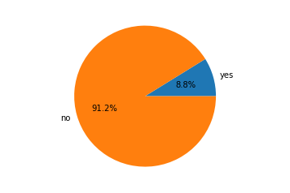

```python
import matplotlib.pyplot as plt
df_no=train[train['class']=='no']
df_yes=train[train['class']=='yes']
class_col=[len(df_yes),len(df_no)]
labels=['yes','no']
plt.axis('equal')
plt.pie(class_col,labels=labels,autopct='%1.1f%%')
plt.show()
```

לפי הגרף ניתן לראות כי הרוב המוחלט של ערכי הסיווג בבסיס הנתונים הוא סיווג שלילי

הרצת המודלים ודיון על התוצאות:

:על מנת שנוכל להשוות בין המודלים, נפעיל את כולם עם עיבוד מקדים זהה

equal frequency, 2 bins

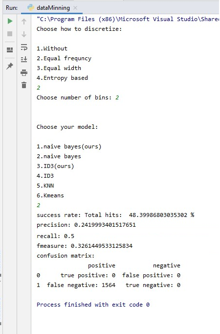

דוגמת הרצה של naive bayes:

ניתן לראות הצלחה בחיזוי של 48% מהערכים

[figure not shown]

דוגמת הרצה של ID3:

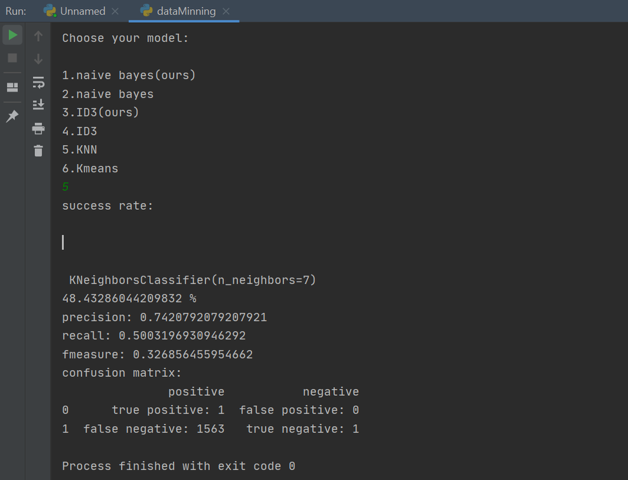

דוגמת הרצה של KNN:

הצלחה בחיזוי של 48.4% מהערכים

לאחר הפעלת המודלים, תוצאות החיזוי של כולם מאוד קרובות זו לזו

המודל המדויק ביותר בהפעלה זו הינו KNN

מכיוון שאחוזי הדיוק מאוד קרובים ולא ניתן לקבוע שיש מודל שעדיף בהקשר הזה, נוכל לבחור את המודל לפי זמן הריצה המהיר ביותר

נסתכל על הרצות המודלים עם כמות גדולה יותר של דליים:

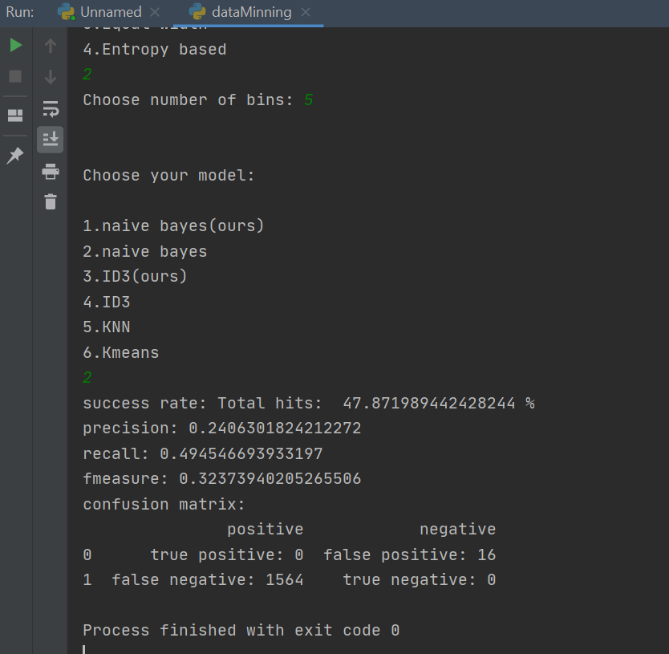

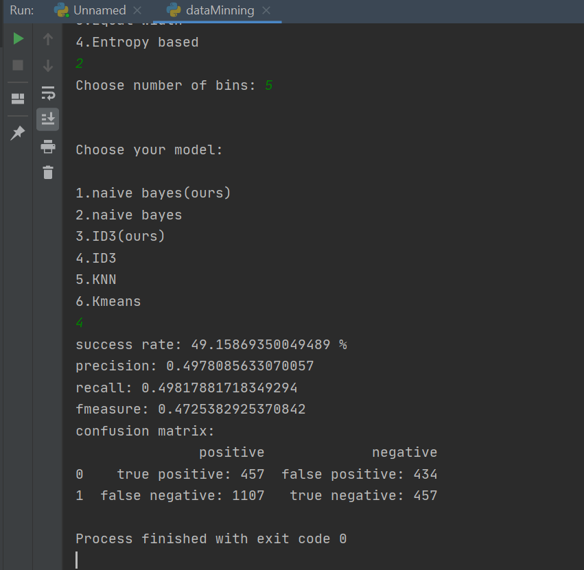

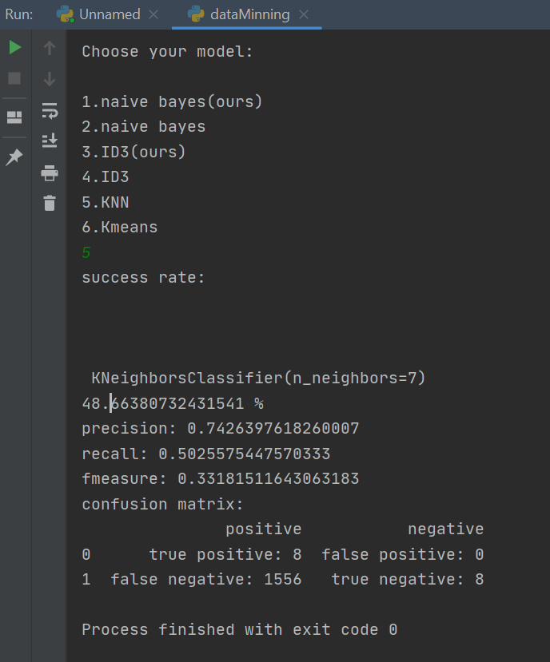

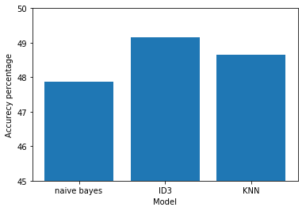

```python
x=['naive bayes','ID3','KNN']
y=[47.87,49.15,48.66]
plt.bar(x,y)
plt.xlabel('Model')
plt.ylabel('Accurecy percentage')
plt.ylim((45,50))

plt.show()
```

גם בהרצה זו, אחוזי ההצלחה של המודלים יחסית קרובים, אבל המודל בעל אחוזי ההצלחה הגבוהים ביותר הוא ID3

לסיכום, תחילה ניתחנו את קבצי הנתונים. מהניתוח עלה שיש לבצע עיבוד מקדים (השלמת ערכים חסרים, מחיקת שורות ללא ערך בעמודת הסיווג, דיסקרטיזציה לערכים נומריים) לאחר העיבוד המקדים הפעלנו את המודלים תחילה עם כמות דליים נמוכה יותר. מצאנו שאין הבדל משמעותי בין אחוזי ההצלחה של המודלים ועל כן לא ניתן לקבוע איזה מודל עדיף בהכרח. לאחר מכן הפעלנו את המודלים עם כמות דליים גדולה יותר, בהפעלה זו היה הבדל משמעותי יותר בין המודלים אבל עדיין קטן. בהפעלה זו המודל בעל אחוזי ההצלחה הגדולים ביותר הינו ID3

על כן כדאי לבחור בו

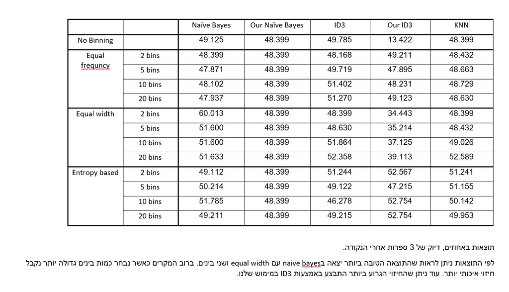